# HW 4

Denys Osmak

2024-02-17

# GITHUB: https://github.com/DenysUkr/SDS-315-GitHub-Repo/tree/10359b653cdd571d4d6a8d115b53a7afbd6fad1b/Homework/HW%204

# Problem 1

### Gas stations charge more if they lack direct competition in sight.

#### Evidence:

```
##        N        Y
## 1.875882 1.852400
```

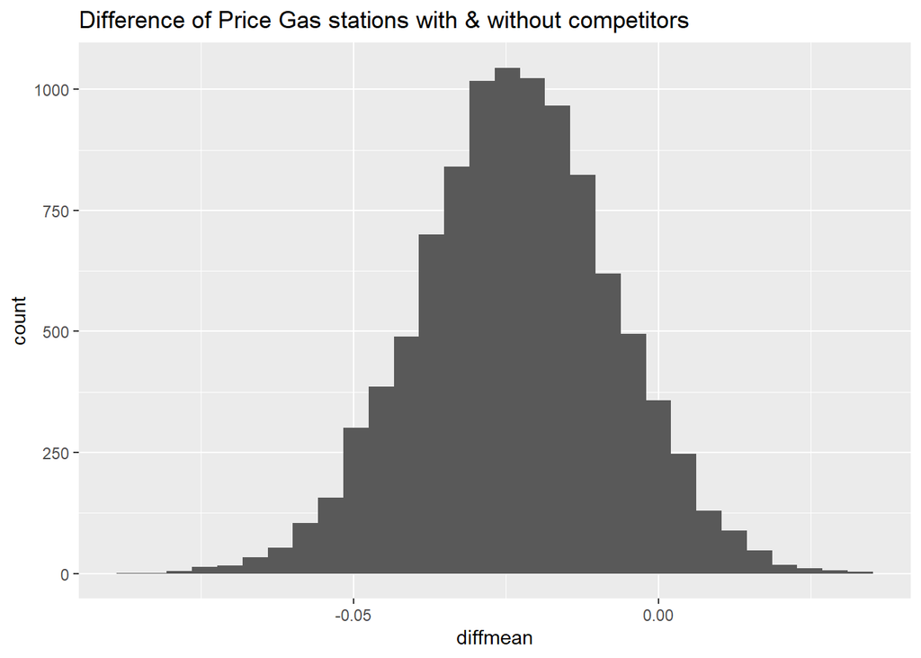

```
##       name       lower       upper level     method    estimate
## 1 diffmean -0.05505583 0.007759563  0.95 percentile -0.02348235
```

#### Conclusion:

We can tell that this claim is false and not supported by the data. In our data set, on average the gas station that did not have any competition nearby had charged 0.02 dollars more per gas vs gas stations with nearby competitors. Applying bootstrapping, with 95% accuracy we can articulate that the wider population of gas stations are charging anywhere from 0.05$ more or to 0.01$ less per gallon, meaning its statistically insignificant.

### Gas stations at stoplights charge more.

#### Evidence:

```
##        N        Y
## 1.866316 1.863016
```

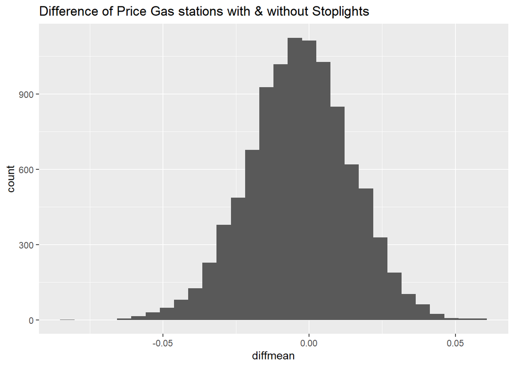

```
##       name       lower      upper level     method     estimate
## 1 diffmean -0.03832913 0.03052739  0.95 percentile -0.003299916
```

### Gas stations with direct highway access charge more.

#### Evidence:

```
##
##  N  Y
## 79 22
```

```
##        N        Y
## 1.854304 1.900000
```

```
##  diffmean
## 0.0456962
```

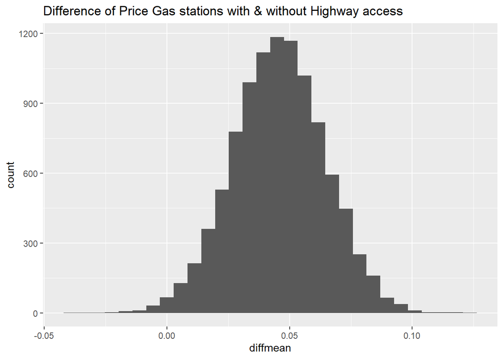

```
##       name       lower      upper level     method  estimate
## 1 diffmean 0.008644851 0.08238217  0.95 percentile 0.0456962
```

#### Conclusion:

From the collected 101 gas stations, the gas stations with highway access charged 4 cents more then gas stations without highway access. However, we can say with 95% confidence that gas stations with highway access can charge anywhere from 0.8 to 8 cents more then gas stations without highway access, making this a statistically significant find, and a practically significant find.

### Shell charges more than all other non-Shell brands.

#### Evidence:

```
##    FALSE     TRUE
## 1.856389 1.883793
```

```
##   diffmean
## 0.02740421
```

```
##
## FALSE  TRUE
##    72    29
```

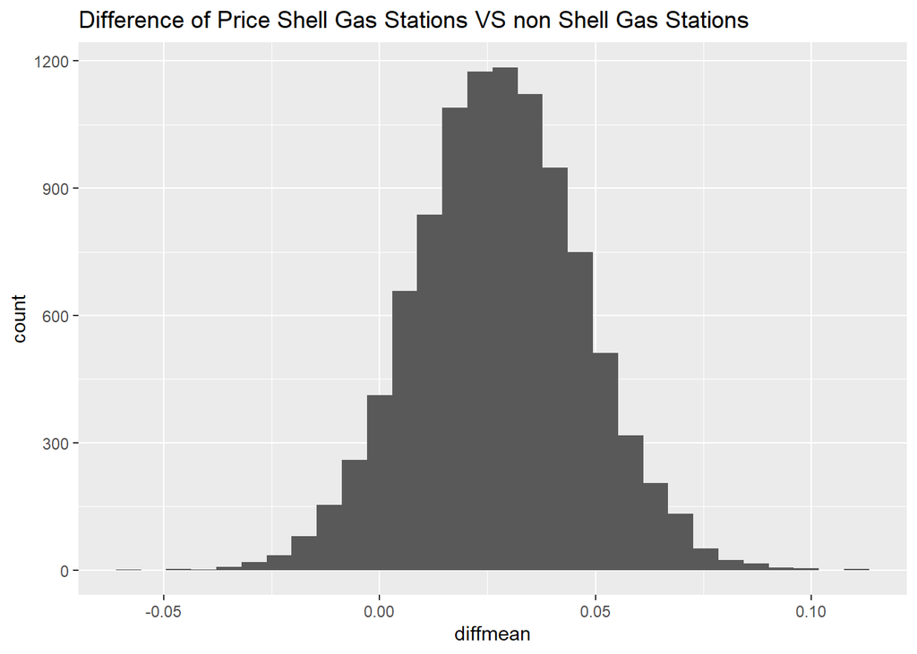

```
##       name       lower      upper level     method   estimate
## 1 diffmean -0.01020252 0.06619125  0.95 percentile 0.02740421
```

#### Conclusion:

From the collected 101 gas stations, the Shell brand gas stations with highway access charged 2 cents more then other brand gas stations However, we can say with 95% confidence that Shell gas stations can charge anywhere from 1 cent less to 6 cents more then other brand gas stations, making this a statistically insignificant find, yet a practically significant find.

# Problem 2

## Part A

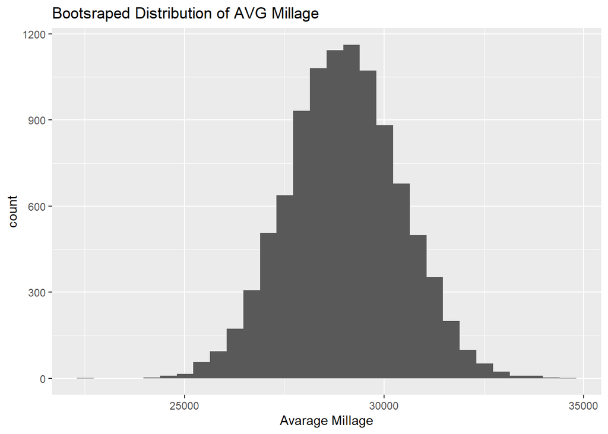

```
##   name    lower   upper level     method estimate
## 1 mean 26282.22 31743.8  0.95 percentile 28997.34
```

### Conclusion:

**The average millage of 2011 63 AMG that hit the market is 28,997 miles +- 2,712.19 miles with 95% confidance**

## Part B

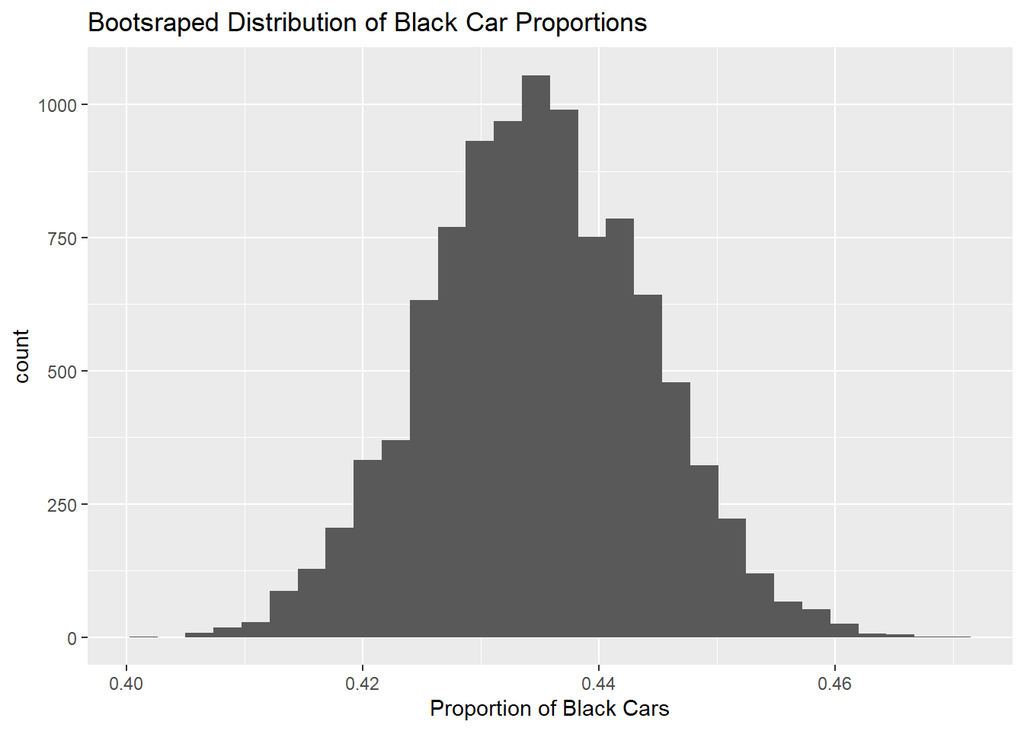

```
##     name     lower    upper level     method  estimate
## 1 n_TRUE 0.4167532 0.453098  0.95 percentile 0.4347525
```

### Conclusion

**I can say with 95% confidence interval that on average 43.475% +-1.834% of all 2014 Mercedes S Class 550 on the used market are Black.**

# Problem 3

## Part A: Does “Living with Ed” or “My name is Earl” make people happier

### Approach:

First we filter all data to living with ed and my name is earl only, then we got a better understanding of the data by finding the mean for the overall data, then we bootstrapped diff mean 10,000 ties with respect to Q1_Happy ~ Show and then created a histrogram of diff mean and grabbed the confidence interval with the “percentile” method

### Evidence:

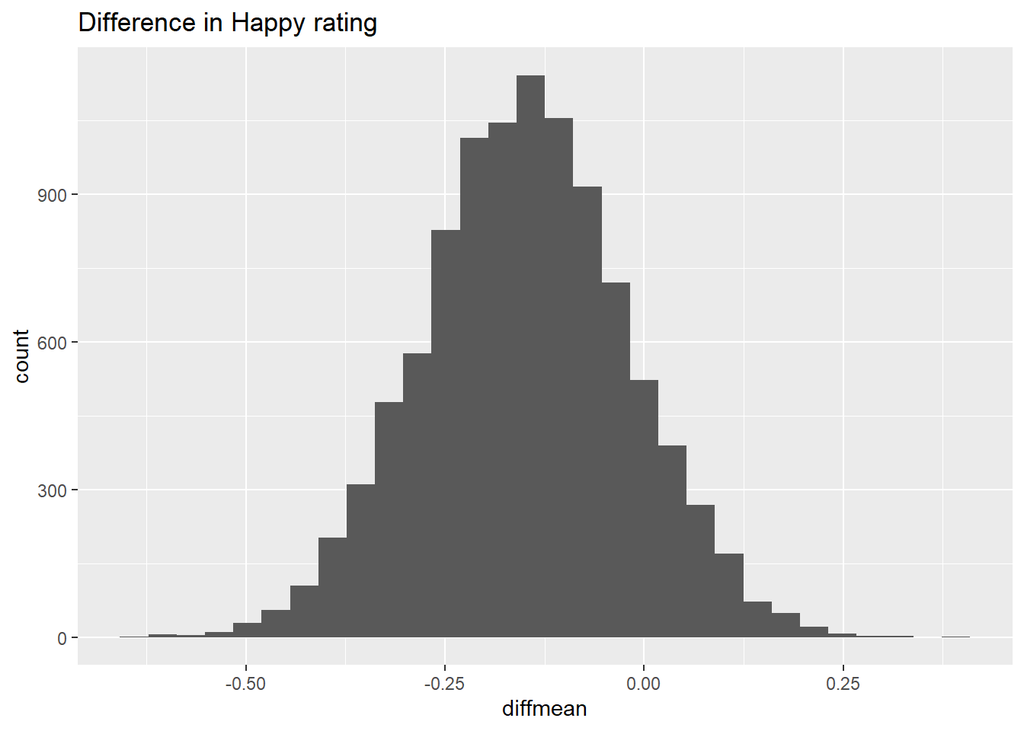

```
##       name      lower     upper level     method   estimate
## 1 diffmean -0.4022671 0.1028172  0.95 percentile -0.1490515
```

## Part B:

### Approach:

First we filter all data to The Biggest Loser” and “The Apprentice: Los Angeles” then we got a better understanding of the data by finding the mean for the overall data, then we bootstrapped diff mean 10,000 ties with respect to Q1_Annoyed ~ Show and then created a histrogram of diff mean and grabbed the confidence interval with the “percentile” method

### Evidence:

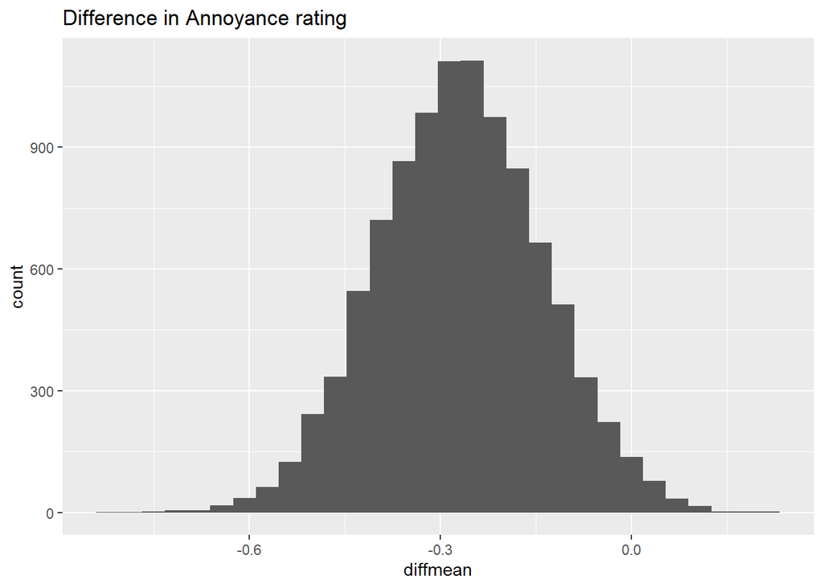

```
##       name      lower       upper level     method  estimate
## 1 diffmean -0.5185099 -0.01386939  0.95 percentile -0.270997
```

### Conclusion:

From the survey “The Apprentice: Los Angles” has been voted as more annoying “The Biggest Loser” in our data set by average 0.27 points (out of 5), and we can say with 95% confidence interval that it produces more annoyance by 0.27+- 0.25 points, it is statistically significant and practically significant to say that this show is producing higher mean for Q1_Annoyance

## Part C:

### Approach:

First we filter all data to Dancing with the Star then we got a better understanding of the data by finding the mean and proportion for the overall data, then we bootstrapped diff mean 10,000 ties with respect to Q2_Confusing~ Show using a custom meathod to find the proportion and then created a histrogram of the proportion and grabbed the confidence interval with the “percentile” method

### Evidence:

[figure not shown]

# Problem 4

## Question: Is the revenue ratio higher when paid ads were turned off or not

## Approach:

First we mututate to find the ratio of reve after and before” then we got a better understanding of the data by finding the mean and rev ratio for the overall data, then we bootstrapped diff mean 10,000 ties with respect to rev_ratio ~ adwords_pause and then created a histrogram of diff mean and grabbed the confidence interval with the “percentile” method

## Evidence:

[figure not shown]

```
##       name       lower       upper level     method    estimate
## 1 diffmean -0.09018963 -0.01317424  0.95 percentile -0.05228145
```

## Conclusion:

**After turning off the ads we can say with 95% confidence that the revenue has dropped 5.23% +- 3.92% after turning off the paid search. Meaning that unless Ebay is spending over 9% of its total revenue on paid ads, making ads unprofitable, the data supports Ebay to continue to pay for ads.**